# Time Series HW 6

Anusha Bhat

2025-02-20

```r
library(TSA)
library(forecast)
library(dplyr)
library(lubridate)
data("beersales")
```

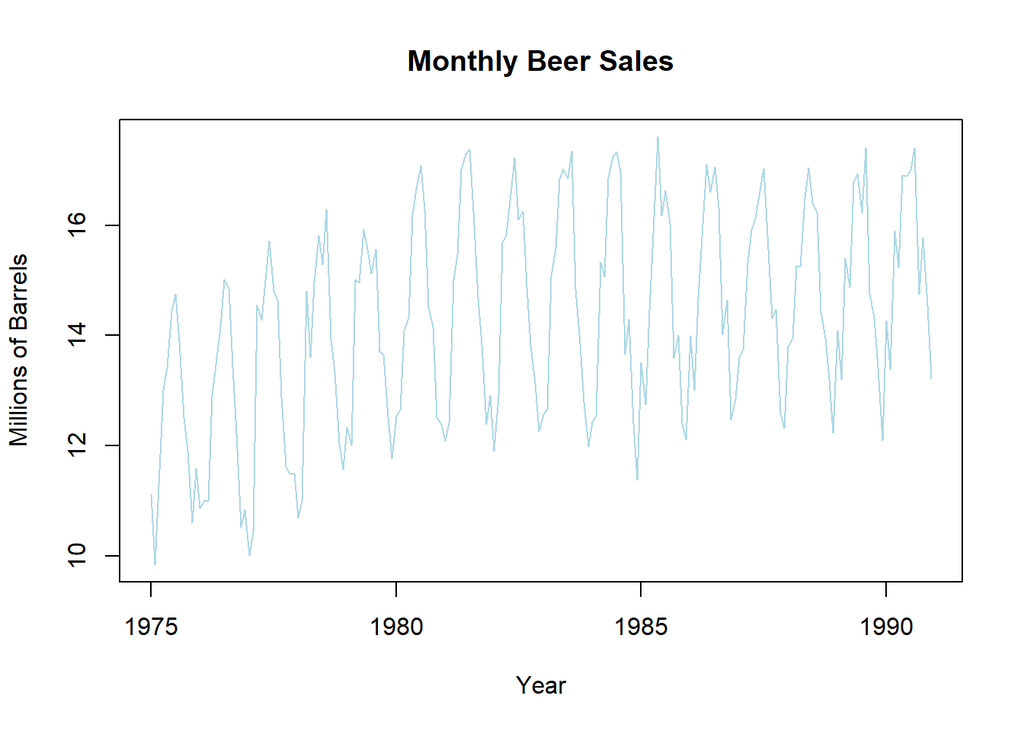

```r
# make TS plot
plot(beersales, main = "Monthly Beer Sales", ylab = "Millions of Barrels",
     xlab = "Year", col = "light blue")
```

```r
# split into train and test

train = window(beersales, start=c(1975,1),
                end=c(1989,12))
test = window(beersales, start=c(1990,1),
               end=c(1990,12))
```

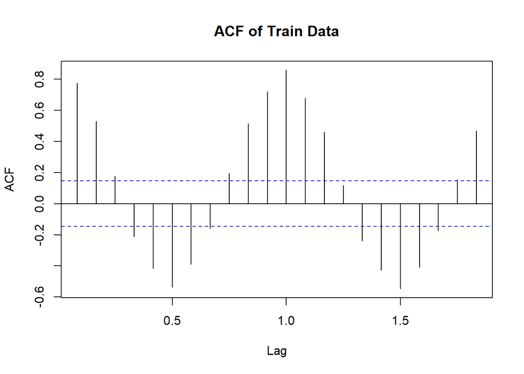

```r
# Check for seasonality
acf(train, main = "ACF of Train Data")
```

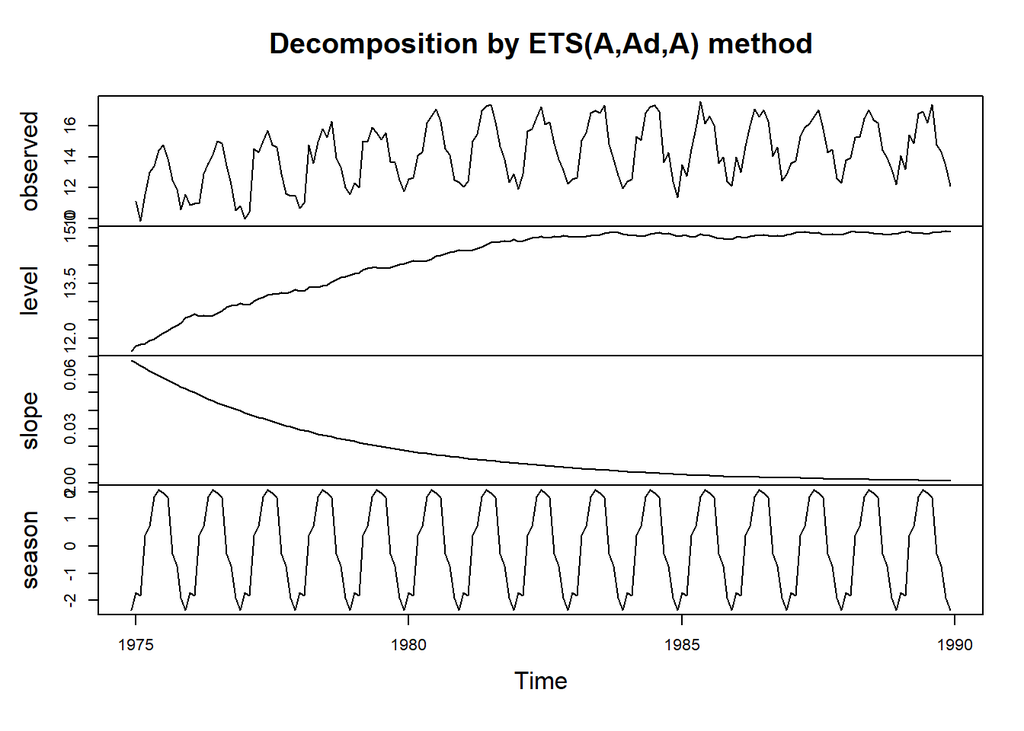

```r
ets = ets(train)
plot(ets)
```

We observe that there potentially is seasonality in our data, so we must account for this with seasonality = TRUE when fitting the auto.arima models for part 1a and 1b.

## Q1a: Recursive Method

```r
# fit the ARIMA(p,d,q) model using auto arima
mod1 = auto.arima(train)

summary(mod1)
```

```
## Series: train
## ARIMA(4,1,2)(2,1,2)[12]
##
## Coefficients:
##          ar1      ar2     ar3      ar4      ma1     ma2    sar1    sar2
##       0.5103  -0.1662  0.1032  -0.3966  -1.1757  0.3125  0.6838  -0.592
## s.e.  0.1453   0.0986  0.0863   0.0789   0.1492  0.1421  0.1451   0.165
##          sma1    sma2
##       -1.1967  0.5849
## s.e.   0.1394  0.2087
##
## sigma^2 = 0.2837:  log likelihood = -134.55
## AIC=291.1   AICc=292.81   BIC=325.4
##
## Training set error measures:
##                       ME      RMSE       MAE       MPE     MAPE      MASE
## Training set -0.01226385 0.4974722 0.3570516 -0.168736 2.535729 0.6855893
##                     ACF1
## Training set 0.001560081
```

```r
# forecast for the next 12 months (1990)
for1 = forecast(mod1, h = 12)
for1$mean
```

```
##           Jan      Feb      Mar      Apr      May      Jun      Jul      Aug
## 1990 13.81601 13.07707 14.96181 15.58503 17.24847 16.86360 16.95571 17.02231
##           Sep      Oct      Nov      Dec
## 1990 14.28619 14.55136 12.89695 12.30127
```

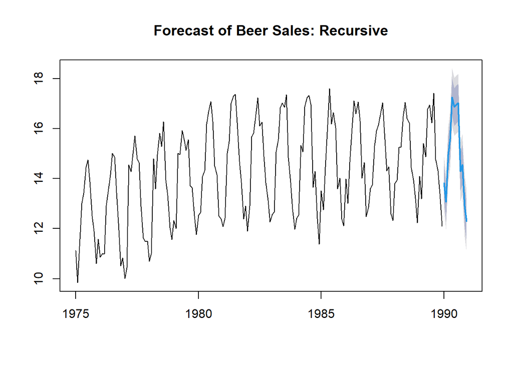

```r
plot(for1, main = "Forecast of Beer Sales: Recursive")
```

## Q1b: DirRec Method

```r
# want to fit an auto.arima model then forecast for h = 1
# add the prediction to train and repeat in a for loop for all 12 months

# create tmp df to preserve train
tmp_train = train

# create vector for results (preds, acf test, mean, normality)
preds = numeric(length(test))
means = numeric(length(test))
p_autocorr = numeric(length(test))
p_normality = numeric(length(test))

for(i in 1:length(test)){

  # fit the model and forecast to train
  mod = auto.arima(tmp_train)
  forecasts = forecast(mod, h = 1)$mean
  preds[i] = forecasts
  #tmp_train = c(tmp_train, forecasts)
  tmp_train = ts(c(tmp_train, forecasts), start = c(1975, 1),
                   frequency = 12)

  # get results
  resids = residuals(mod)
  means[i] = mean(resids)
  lb_test = Box.test(resids, type = "Ljung-Box")
  p_autocorr[i] = lb_test$p.value
  sw_test = shapiro.test(resids)
  p_normality[i] = sw_test$p.value
}

preds
```

```
##  [1] 13.81601 13.07601 14.95918 15.58647 17.25355 16.85710 16.95755 17.02034
##  [9] 14.27249 14.55724 12.88748 12.30538
```

## Q1c: Checking Residuals

### Checking Residuals for the Recursive Method:

```r
# get residuals from model
resids1 = residuals(mod1)
```

```r
# check mean
cat("Mean of Residuals Recursive:", round(mean(resids1), 5))
```

```
## Mean of Residuals Recursive: -0.01226
```

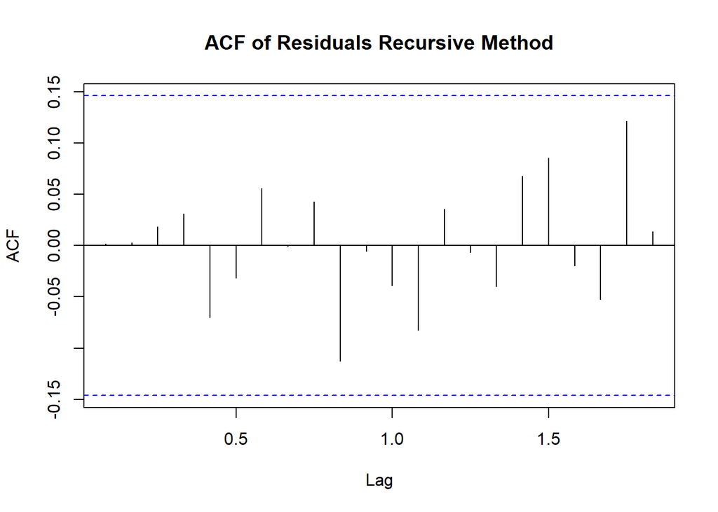

```r
# check ACF plot
acf(resids1, main = "ACF of Residuals Recursive Method")
```

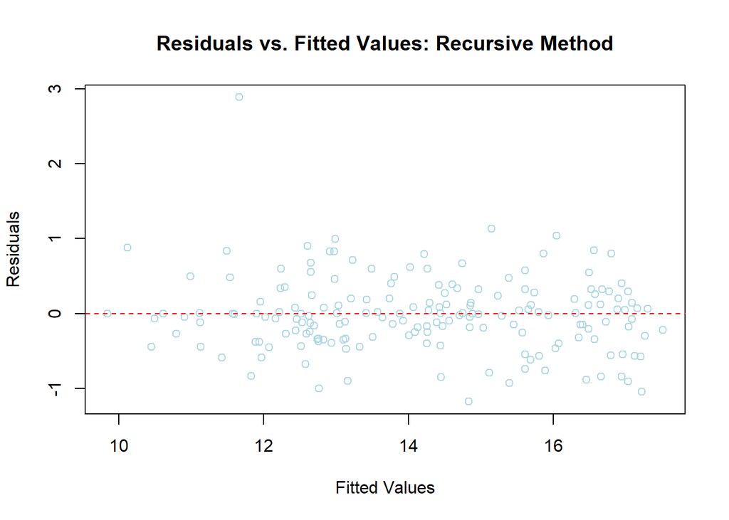

```r
# plot residuals vs. fitted values to examine the residuals
fits1 = fitted(mod1)
plot(y = resids1, x = fits1,
     main = "Residuals vs. Fitted Values: Recursive Method",
     ylab = "Residuals",
     xlab = "Fitted Values", col = "Light Blue")
abline(h = 0, col = "red", lty = 2)
```

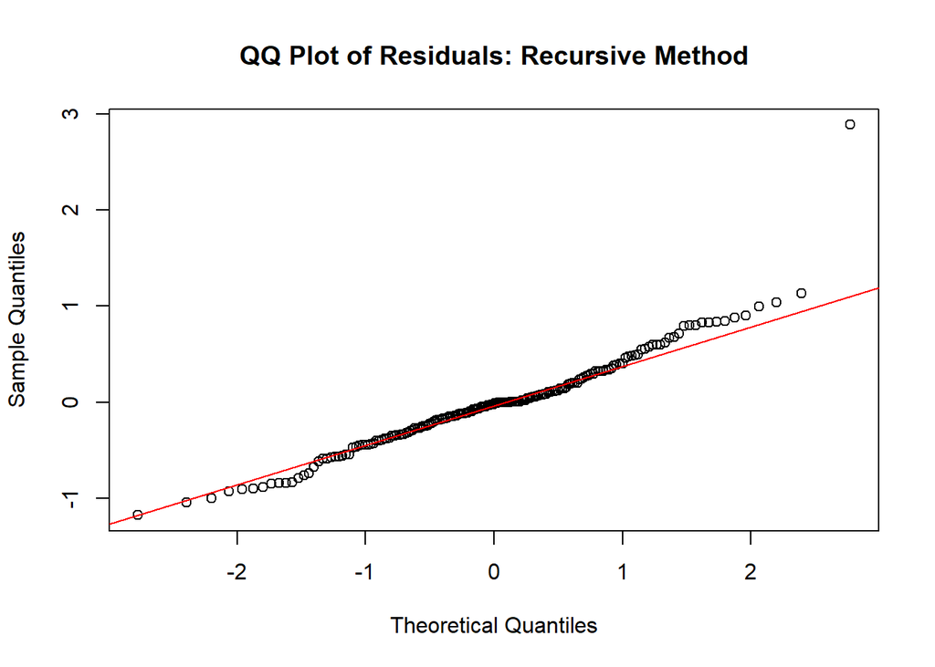

```r
qqnorm(resids1, main = "QQ Plot of Residuals: Recursive Method")
qqline(resids1, col = "red")
```

```r
# LB test for auto correlation
lb1 = Box.test(resids1, type = "Ljung-Box", lag = 12)
lb1
```

```
##
##  Box-Ljung test
##
## data:  resids1
## X-squared = 5.0383, df = 12, p-value = 0.9567
```

```r
sw1 = shapiro.test(resids1)
sw1
```

```
##
##  Shapiro-Wilk normality test
##
## data:  resids1
## W = 0.93789, p-value = 5.15e-07
```

Based on the ACF plot, we see that the lags are not significantly autocorrelated with each other. The LB autocorrelation test returns a p-value greater than 0.05, so we fail to reject the null hypothesis that the residuals are not autocorrelated. The residuals have a mean close to 0, are evenly distributed with no heteroskedascity in the residuals vs. fitted values plot, and they fall closely to the Normal on the QQ plot. However, the Shapiro-Wilkes test returns a p-value much less than 0.01, so we reject the null hypothesis and conclude that the residuals are not normal. The residuals are not normal but they have no autocorrelation and approximately zero mean with constant variance, therefore they are random noise (but not Gaussian white noise specifically).

### Checking Residuals for the DirRec Method:

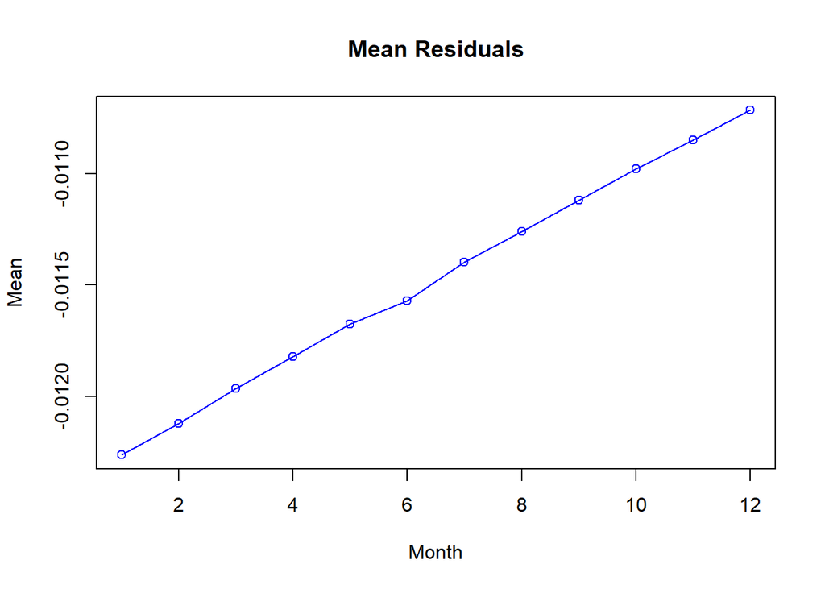

```r
plot(means, type = "o", col = "blue", main = "Mean Residuals",
     ylab = "Mean", xlab= "Month")
```

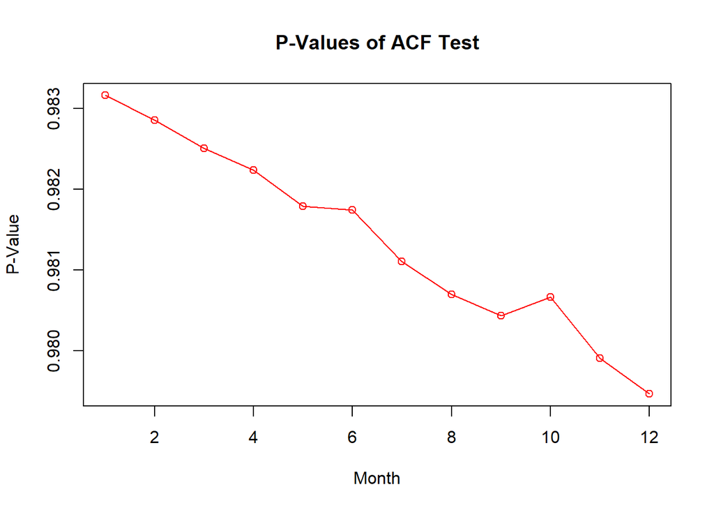

```r
plot(p_autocorr, type = "o", col = "red", main = "P-Values of ACF Test",
      ylab = "P-Value", xlab = "Month")
```

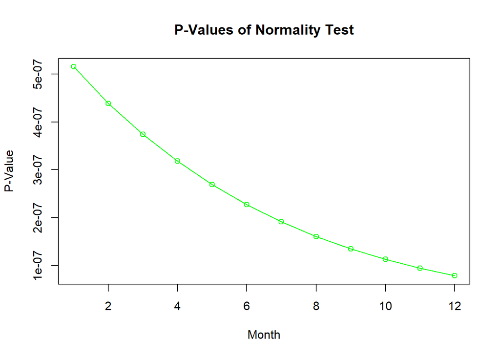

```r
plot(p_normality, type = "o", col = "green", main = "P-Values of Normality Test",
      ylab = "P-Value", xlab = "Month")
```

We observe that the means of the residuals are close to 0 for each of the 12 models. We also observe that the p-values for the LB test are all higher than 0.05, so for each model, we fail to reject the null hypothesis, indicating that the residuals are not autocorrelated. However, the normality test has p-values much less than 0.01 for each model, so we reject the null hypothesis and conclude that the residuals for each model are not normal. The residuals are not normal but they have no autocorrelation and approximately zero mean with constant variance, therefore they are random noise (but not Gaussian white noise specifically).

## Q2: Plot Recursive and DirRec Along With Actuals

```r
# convert preds into a ts first
preds_new = ts(preds, start = c(1990, 1), frequency = 12)
```

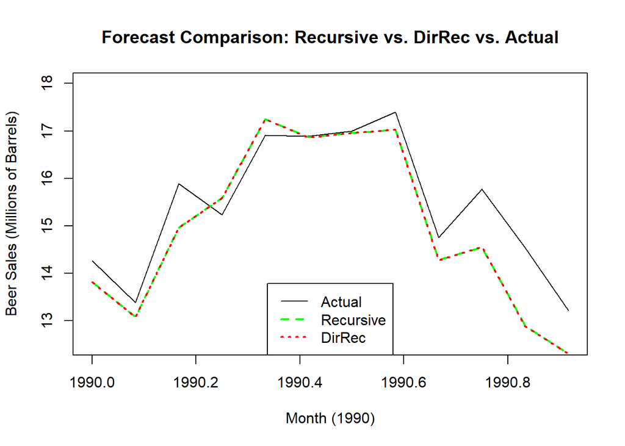

```r
plot(test, type = "l", col = "black", ylim = c(12.5, 18),
     main = "Forecast Comparison: Recursive vs. DirRec vs. Actual",
     ylab = "Beer Sales (Millions of Barrels)", xlab = "Month (1990)")
lines(for1$mean, col = "green", lty = 2, lwd = 2)
lines(preds_new, col = "red", lty = 3, lwd = 2)

legend("bottom", legend = c("Actual", "Recursive", "DirRec"),
       col = c("black", "green", "red"),
       lwd = c(1, 2, 2), lty = c(1, 2, 3))
```

```r
for1$mean
```

```
##           Jan      Feb      Mar      Apr      May      Jun      Jul      Aug
## 1990 13.81601 13.07707 14.96181 15.58503 17.24847 16.86360 16.95571 17.02231
##           Sep      Oct      Nov      Dec
## 1990 14.28619 14.55136 12.89695 12.30127
```

```r
preds_new
```

```
##           Jan      Feb      Mar      Apr      May      Jun      Jul      Aug
## 1990 13.81601 13.07601 14.95918 15.58647 17.25355 16.85710 16.95755 17.02034
##           Sep      Oct      Nov      Dec
## 1990 14.27249 14.55724 12.88748 12.30538
```

There’s some slight differences between the two predictions, so the lines will overlap in the plot for the two models. However, the predictions over time for both models closely follow the trend for the actual values.

## Question 3: Calculate MSE

```r
mse_rec = mean((test - for1$mean)^2)

cat("MSE Recursive:", mse_rec)
```

```
## MSE Recursive: 0.5650021
```

```r
mse_dir = mean((test - preds_new)^2)

cat("MSE DirRec:", mse_dir)
```

```
## MSE DirRec: 0.5678293
```

The DirRec forecasting method takes a larger computation time since the model has to be fitted recursively 12 times whereas the recursive method only has to be fit once to predict the next 12 months. The additional models that need to be fit in the DirRec method increase the computation complexity of the method, causing it to take more time.

# Part B:

```r
cme = read.csv("cmeS.csv")
imm = read.csv("immS.csv")
iom = read.csv("iomS.csv")
```

```r
# function for algorithm to clean time series
clean_time_series <- function(df) {
  # put correct date format then sort by date
  df$DateOfSale <- as.Date(df$DateOfSale, format = "%m/%d/%Y")
  df <- df %>% arrange(DateOfSale)

  # create new df for cleaned data
  dates <- seq(as.Date("2001-01-01"), as.Date("2013-12-31"), by = "month")
  new_df <- data.frame(Date = dates, Price = NA)

  # loop through each month and fill in the prices
  # take median if multiple prices and do forward fill if missing
  for (i in 1:nrow(new_df)) {
    month_tmp <- df %>%
      filter(year(DateOfSale) == year(new_df$Date[i]) &
               month(DateOfSale) == month(new_df$Date[i]))

    if (nrow(month_tmp) > 0) {
      # median
      new_df$Price[i] <- median(month_tmp$price, na.rm = TRUE)
    } else {
      # forward fill
      if (i > 1) {
        new_df$Price[i] <- new_df$Price[i - 1]
      }
    }
  }
  # return cleaned data
  return(new_df)
}
```

```r
# apply the function to each dataset
cme_new = clean_time_series(cme)
imm_new = clean_time_series(imm)
iom_new = clean_time_series(iom)
```

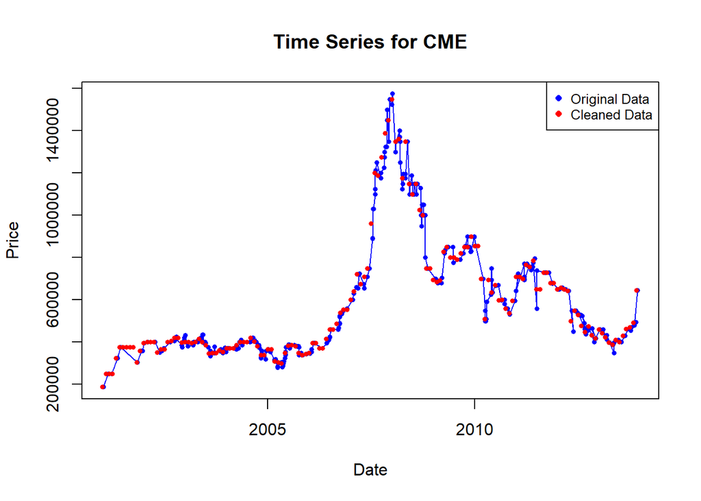

```r
# plots for original vs cleaned data: CME
cme_tmp = cme
cme_tmp$Date <- as.Date(cme$DateOfSale, format = "%m/%d/%Y")


plot(cme_tmp$Date, cme$price, type = "o", col = "blue",
     xlab = "Date", ylab = "Price", main = "Time Series for CME",
     pch = 16, cex = 0.6, ylim = range(c(cme$price, cme_new$Price)))

points(cme_new$Date, cme_new$Price, col = "red", pch = 16, cex = 0.6)

legend("topright", legend = c("Original Data", "Cleaned Data"),
       col = c("blue", "red"), pch = 16, cex = 0.8)
```

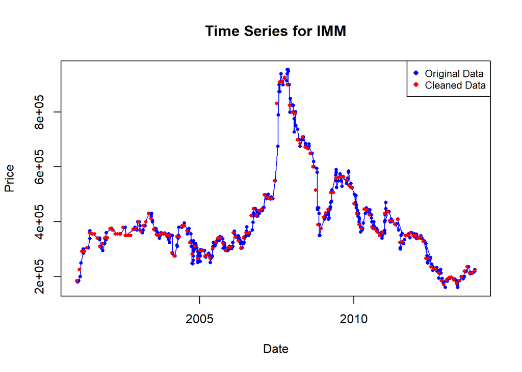

```r
# plots for original vs cleaned data: IMM
imm_tmp = imm
imm_tmp$Date <- as.Date(imm$DateOfSale, format = "%m/%d/%Y")


plot(imm_tmp$Date, imm$price, type = "o", col = "blue",
     xlab = "Date", ylab = "Price", main = "Time Series for IMM",
     pch = 16, cex = 0.6, ylim = range(c(imm$price, imm_new$Price)))

points(imm_new$Date, imm_new$Price, col = "red", pch = 16, cex = 0.6)

legend("topright", legend = c("Original Data", "Cleaned Data"),
       col = c("blue", "red"), pch = 16, cex = 0.8)
```

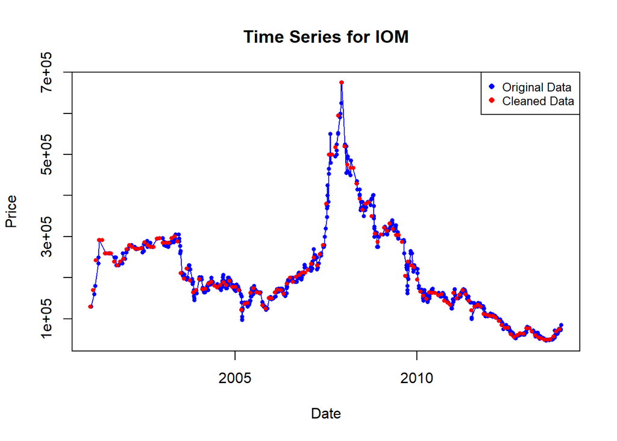

```r
# plots for original vs cleaned data: IOM
iom_tmp = iom
iom_tmp$Date <- as.Date(iom$DateOfSale, format = "%m/%d/%Y")


plot(iom_tmp$Date, iom$price, type = "o", col = "blue",
     xlab = "Date", ylab = "Price", main = "Time Series for IOM",
     pch = 16, cex = 0.6, ylim = range(c(iom$price, iom_new$Price)))

points(iom_new$Date, iom_new$Price, col = "red", pch = 16, cex = 0.6)

legend("topright", legend = c("Original Data", "Cleaned Data"),
       col = c("blue", "red"), pch = 16, cex = 0.8)
```

I used this method because I thought that it would be easiest to loop through each month sequentially to get the prices in correct time order, especially since we can sort by the date. Due to going forward in time, I decided to use forward fill as the imputation method rather than backwards or taking the mean or median of all of the prices. Additionally, since prices can vary so much, I decided to take the median if there is more than one price rather than the mean as median is less resistant to outliers and skewing compared to mean. At first I tried to run this algorithm using the Year and Month columns given in the original data frame, but this failed for the IOM dataset since it had some missing values in the Year and Month columns and they were stored as strings rather than ints like the other two datasets. After a lot of trial and error and debugging, I landed on using the DateofSale column to sort the data then manually creating a date range for the new dataframe.